# KARI_analysis

### Author: Natasha Seelam

The following notebook higlights the usage of the "EnzymeAnalysis" class.

The following packages are required to run:

- python version 3.7.3
- pandas == 0.25.3
- numpy == 1.17.4
- sklearn (for joblib) == 0.22.1
- MDAnalysis == 0.20.1
- matplotlib == 3.2.1
- re == 2.2.1
- nglview == 2.7.1
- pytraj == 2.0.4

I implemented the following in a specific Anaconda environment.

Please note, at the time, sklearn included joblib (hence the older version of the package). This will be deprecated in future versions and must be adapted to use "joblib" standalone.

In my doctoral work, I make simulations of proteins doing chemical reactions. This involves studying how atoms inside a protein move, particularly when a reaction is happening. For example, take a look at the following figure:

[figure not shown]

This is a dynamic process of atoms moving in a molecule!

My research involves trying to understand *why* they move this way, and by using ML techniques to explore this. However, before I can do that, I need to be able to extract useful information out of static, xyz coordinates. For every model I create, there are xyz-coordinates of every atom, for every time-step within a simulation. I need to take these coordinates, and convert them into a text file for another program. The following JupyterNotebook demonstrates how I built a class to do the following:

1. Extract positions of atoms (340 total from the xyz coordinates to 32 atoms of interest) from binary files
2. Compute geometric features off the positions of these atoms
3. Use the position of these atoms to write an input file **for another program** that will help me extract features of interest.

Note, in order to even build my ML methods, I required many steps of processing on very low-level binary files. This is one of the ways I automated, and streamlined this process.

In the following block, I will load the necessary python packages I use to process (read/write) a **variety of different files, some of which were made from FORTRAN, custom-software like CHARMM, MATLAB, text files, and require compatibility between them.**.

```python
#Make notebook cleaner; all warnings are for deprecation. This is unnecessary for function
import warnings
warnings.filterwarnings('ignore')

#Numerics
import numpy as np
import pandas as pd
from numpy.linalg import norm


#Data Storage
from sklearn.externals import joblib as jb
#import hdf5storage #This is helpful in reading MATLAB files; you can omit

#Molecular Dynamics analysis (Read/Write DCD)
import MDAnalysis
import nglview as nv
from Bio.PDB import PDBParser as pp

#External functions
import sys
import glob
from analysisFunctions import * #All functions used
from analyzeChemistry import *  #1 Object used

#Plotting
import matplotlib.pyplot as plt
%matplotlib inline
```

Before we begin, we want to visualize a 3D view of the proteins of interest. In the folder of interest, I load an example of the xyz coordinates of interest.

In the following 2 blocks, I will show you:

1. A subset of the PDB file, in the form of written lines
2. A 3D representation of the protein expressed in that text file.

```python
#Here is what the text file represents in terms of written text lines.
with open('trimtest.pdb', 'r') as f:
    prot = f.readlines()

#Show first 10 lines
for line in prot[:10]:
    print(line)
```

```
REMARK  NONE *

REMARK   DATE:     8/13/16     12:41:32      CREATED BY USER: brian

ATOM      1  N   GLN   136      10.890   3.806   3.200  1.00 -0.47      A

ATOM      2  HN  GLN   136      10.730   3.124   3.910  1.00  0.31      A

ATOM      3  CA  GLN   136      10.277   5.101   3.357  1.00  0.07      A

ATOM      4  HA  GLN   136      10.027   5.495   2.383  1.00  0.09      A

ATOM      5  CB  GLN   136       9.013   4.891   4.216  1.00 -0.18      A

ATOM      6  HB1 GLN   136       8.836   5.814   4.807  1.00  0.09      A

ATOM      7  HB2 GLN   136       9.201   4.048   4.913  1.00  0.09      A

ATOM      8  CG  GLN   136       7.713   4.574   3.399  1.00 -0.18      A
```

```python
#Load the pdb in 3D form
view = nv.show_structure_file('trimtest.pdb')
view.clear()
view.add_representation(repr_type = 'licorice', selection = 'all')
view.add_representation(repr_type = 'ball+stick', selection = [i for i in range(309, 341)], color = 'green')

view.camera = 'orthographic'
view.center()
view
```

```python
view.render_image()
```

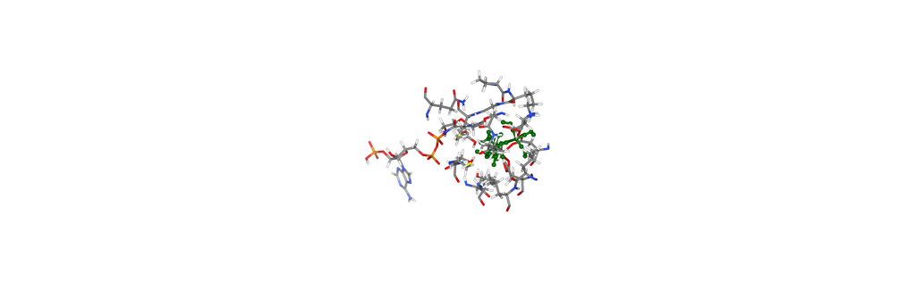

```python
view._display_image()
```

The above is the entire set of coordinates, with the region of green being the part of the protein we want to consider for subsequent modeling.

For the rest of the modeling, we specify the save directories, cluster ID, timesteps of the simulation, and regions of interest within the protein. These do require domain-expertise, but are highly relatable for protein computational chemists.

```python
# User Parameters

#Location of the cluster-file DCDs
clusterloc = "input/"

#Pythonic index of the atoms you want to save
qmregion = np.arange(309, 341)

#Reaction coordinate atoms in the newly saved QMregion
rxncoor = [3, 4]

#Number of trajectories
Ntrajs = 10

#Cluster number
clusters = [5]

#Distribution ensemble
ensemble = 'nonreac'

#Columns of your default PDB; THESE ARE STANDARD FOR PDB PROCESSING.
pdbcolumns = [ "Atom",
               "Atom ID",
               "Atom Type",
               "Res", "Res ID",
               "X Coor",
               "Y Coor",
               "Z Coor",
               "B-factor",
               "Charge",
               "Chain ID"]

#Number of timepoints backwards
trev = 50

#Number of timepoints forward
tfor = 70

#Filtered Trajectory timepoints
time = np.arange(-trev, tfor + 1)
```

The next cell block requires user input. It will ask how many features you want, what kind of geometric features (distances, angles, torsions) and requires the user to specify the atomID (which must be known, and is known for computational chemists).

```python
#The features you want to compute:
features = { "Nfts" : 30,
             "geo_keys" : ["dist", "angs", "tors"],
             "dist"  : [[100, 313],
                        [336, 314],
                        [338, 314],
                        [332, 314],
                        [316, 155],
                        [331, 314],
                        [313, 312],
                        [328, 325],
                        [315, 317],
                        [325, 314],
                        [ 12, 305],
                        [335, 314],
                        [312, 315],
                        [314, 324],
                        [309, 312],
                        [324, 311],
                        [327, 325],
              ],
             "angs" : [[335, 327, 325],
                       [298, 293, 288],
                       [325, 314, 324],
                       [314, 324, 311],
                       [309, 312, 315],
                       [316, 325, 314],
                       [ 12,  14, 305],
                       [313, 315, 317],
                       [333, 326, 325],
                       [336, 327, 325],
                       [339, 330, 324],
                       [337, 329, 324],
                       ],
             "tors" : [[ 313, 312, 315, 317]]}
```

```python
# --------------------
# QCHEM PARAMETERS
# -------------------
#Directory you want to save q-chem files in
qchemdir = "output/"

#Directory to save files in
sdir = "output/"

#List of the atoms
atomnames = ['   C','   O','   O','   C','   C','   O','   C','   O','   C','   H','   H','   H','   H','   H','   H','  Mg','  Mg','   O','   O','   O','   O','   O','   H','   H','   H','   H','   H','   H','   H','   H','   H','   H']

#System charge
charge = 2

#System multiplicity
multiplicity = 1

#Q-chem Job Parameters

job_parameters = { "JOBTYPE" : "sp",
                   "EXCHANGE" : "b3lyp",
                   "BASIS" : "6-31G(d)",
                   "GUI" : "=2",
                   "NBO" : "true"}

nbo_parameters = {"nbosum" : "",
                  "cmo" : "",
                  "BNDIDX" : "",
                  "3CHB" : "",
                  "3CBOND" : ""}
```

```python
# Load the Enzyme Analysis Object
a = EnzymeAnalysis(qmregion = qmregion,
                   Ntrajs = Ntrajs,
                   pdbcolumns = pdbcolumns,
                   clusterloc = clusterloc,
                   rxncoor = rxncoor,
                   features = features)


#Initialize with all trajectory files with unique coordinates
a.initUniqueDCDfiles(ensemble = ensemble)

#Load the desired coordinates
a.loadTrajs(clustid = clusters, nmod = 1)

#Filter trajectories for the required timepoints; this throws away "bad" simulations.
a.filterTrajs(trev = trev, tfor = tfor, Ntraj_short = True, keep_trajs = True, Nmin = None)
```

```
Using Default pdb directory for N.Seelam
Finished loading the NonReactive DCD Map File
Completed loading map in self.tloc, self.Nclust
For nonreac finding unique DCD files across the clusters.
Completed loading map of UNIQUE DCDs in self.tloc, self.Nclust
Iteration = 1/10
Iteration = 2/10
Iteration = 3/10
Iteration = 4/10
Iteration = 5/10
Iteration = 6/10
Iteration = 7/10
Iteration = 8/10
Iteration = 9/10
Iteration = 10/10
Finished collecting trajectories for cluster = 5
Saving the original DCD files as self.old_traj
Updated nonreac trajectory to have to new Nframes, 121
```

For visualization purposes, show how we've modeled the coordinates of the "reaction-coordinates". This is considering the distance between C4-C5 and C5-C7, the former a bonded pair of atoms and the latter a broken pair of atoms. What you expect to see is a series of trajectories that oscillate (like a sine-wave), stretch quite far after t = 0, and then return back to what would be a typical oscillation.

```python
#Compute 2 reaction coordinates. C4C5 and C5C7
lambda_2 = { clustid : [] for clustid in clusters}
for clustid in clusters:
    for trajidx in range(a.trajs[clustid]["Trajs"].shape[0]):
        r2 = get_rxncoor(trajdcd = a.trajs[clustid]["Trajs"][trajidx, :, :, :], rxncoor_atoms = [4, 6], fxnkey = 'dist')
        lambda_2[clustid].append(r2)
    lambda_all = {clustid: [np.vstack([a.trajs[clustid]["lambda"][trajidx], lambda_2[clustid][trajidx]]) for trajidx in range(a.Ntrajs)]}
```

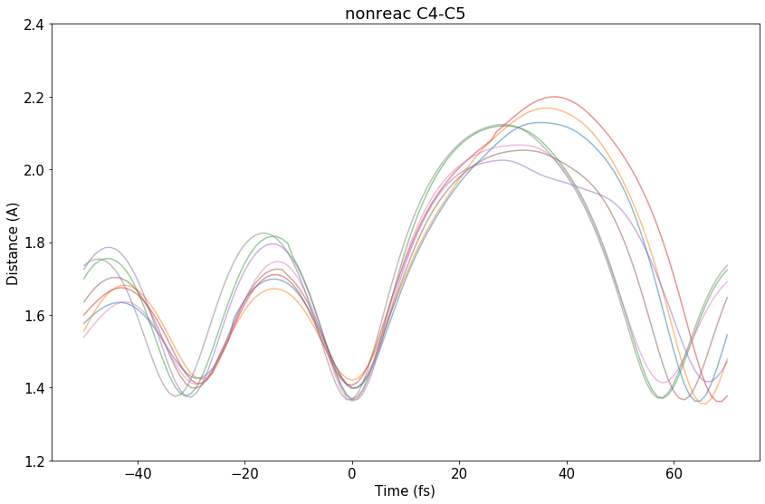

```python
#Plot Trajectories
plt.rcParams['font.size'] = 15
f = plt.figure(figsize = (12,8))
ax = f.add_subplot(1,1,1)
for idx in range(a.Ntrajs):
    ax.plot(time, a.trajs[clustid]['geofts'][idx, :, 6], alpha = 0.5)


ax.set_yticks(np.arange(1.2, 2.9, 0.2))
ax.set_ylim([1.2, 2.4])
ax.set_xlabel("Time (fs)")
ax.set_ylabel("Distance (A)")
ax.set_title(ensemble + " C4-C5")
f.tight_layout()
```

```python
a.makeQchem(clustid = clustid,
            qchemdir = qchemdir,
            atomlist = atomnames,
            job_parameters = job_parameters,
            nbo_parameters = nbo_parameters,
            charge = charge,
            multiplicity = multiplicity,
            lambda_value = lambda_all[clustid])
```

```
Making qchem files for nonreac, cluster 5
```

We now want to see that our program was capable of creating files of interest. To do this, it will be in "output/nonreac/cluster5/". We will look at a few examples:

```python
glob.glob(qchemdir + "*/*/*")
```

```
['output/nonreac/cluster5/traj2',
 'output/nonreac/cluster5/traj8',
 'output/nonreac/cluster5/traj5',
 'output/nonreac/cluster5/traj1',
 'output/nonreac/cluster5/traj6',
 'output/nonreac/cluster5/traj4',
 'output/nonreac/cluster5/traj9',
 'output/nonreac/cluster5/traj3',
 'output/nonreac/cluster5/traj7',
 'output/nonreac/cluster5/traj10']
```

We see a few directories made. We'll take an example of one such directory

```python
#An example file
tmp_file = glob.glob(qchemdir + "*/*/*/*")[0]
print("File name", tmp_file)

with open(tmp_file, "r") as f:
    x = f.readlines()


for line in x:
    print(line)
```

```
File name output/nonreac/cluster5/traj2/nonreac_clust5_traj2_fr77.qcin
$rem

   JOBTYPE sp

   EXCHANGE b3lyp

   BASIS 6-31G(d)

   GUI =2

   NBO true

$end



$comment

lam 1 : 2.079

lam 2 : 2.174

/data/brian/kari/constrained_p/reactive_ensembles/ens2/nonreact/set_4_long/prod_rev_00456_trim.dcd

$end



$nbo

   nbosum

   cmo

   BNDIDX

   3CHB

   3CBOND
```

[output cut: 59 more lines]

```
       H      -2.627     1.965     0.253

       H      -2.691    -0.863     1.165

       H      -2.003    -1.020     2.497

       H       2.226    -0.166     6.919

       H       3.076     0.326     5.749

       H       1.879    -3.172     5.805

       H       1.123    -2.290     6.830

$end
```

From the above, we see that our object has successfully created the file of interest. These files are then used to generate new simulations.